# NMDS

Venus van Hoof

**NMDS**

The code executes a nmds and nmds plot using the vegan package. The ASV abundance matrix is hellinger transformed and distances are calculated based on Bray-curtis distance. Data from all sampling locations are included. Different colours are given from sampling locations from reefs and marine lakes.

```r
setwd("C:/Users/Venus/OneDrive/Documents/Github/RajaAmpat_forams")

library(tidyverse)
library(vegan)
library(extrafont)
library(fitdistrplus)
library(ggh4x)
library(car)
library(FSA)
library(pairwiseAdonis)

df <- read.csv("Rdata/working_dataset.csv")
foram_df <- subset(df, df$Phylum == "Foraminifera")
foram_sp <-  foram_df[foram_df$X.Identity.percentage > 99.4,]

###----------------------------NMDS plot for marine lakes and reefs (ASV)------------------------------------
#make ASV table matrix
foram_df %>%
  dplyr::select(otu, seqid,reads) %>%
  pivot_wider(names_from = otu, values_from = reads, values_fill = list(reads = 0)) %>%
  as.data.frame()-> foram_df1
dim(foram_df1) #106 samples and 2981 ASVs

rownames(foram_df1) <- foram_df1$seqid
foram_df1 <- foram_df1[, -1]
foram_df1 <- as.matrix(foram_df1)

#hellinger transformation
foram_hell <- decostand(foram_df1, method = "hellinger")

#calculate nmds
set.seed(1)
nmds <- metaMDS(foram_hell, distance= "bray", trymax=100, maxit = 1000, k=2) #stress = 0.192083
stressplot(nmds)

#add metadata
foram_df %>%
  dplyr::select(seqid, Location, Habitat, Benthic.group) %>%
  unique()-> foram_metadat

#plot nmds
scores(nmds, display = "sites") %>%
  as_tibble(rownames = "seqid") %>%
  inner_join(foram_metadat, by = "seqid") %>%
  ggplot(aes(x = NMDS1, y = NMDS2, color = Habitat)) +
  geom_point(size= 3) +
  scale_color_manual(values = c("Reef" = "#39568CFF", "Marine Lake" = "#55C667FF")) +
  theme_bw() +
  theme(text = element_text(family = "Arial", face = "plain"),
        legend.text = element_text(size = 14),
        legend.title = element_text(size = 14),
        axis.title = element_text(size = 16, face = "bold", hjust = 0.5)) -> nmds_all

ggsave("Graphs/nmds_all.svg",
       plot = nmds_all,
       device = "svg",
       width = 12,
       height = 6,
       dpi = 300)

adonis2(foram_hell~Habitat,data=foram_metadat,method="bray")
```

[output not shown]

Because the reefs are signficantly different from the marine lakes, different nmds plots are made for the reefs and marine lakes.

```r
setwd("C:/Users/Venus/OneDrive/Documents/Github/RajaAmpat_forams")
###----------------------------NMDS plot reefs (ASV)--------------------------------------

#make ASV table matrix
foram_df %>%
  filter(!Location %in% c("MIS23", "MIS26", "MIS27", "MIS06")) %>%
  dplyr::select(otu, seqid,reads) %>%
  pivot_wider(names_from = otu, values_from = reads, values_fill = list(reads = 0)) %>%
  as.data.frame()-> foram_reef
dim(foram_reef) #87 samples and 2741 ASVs
```

```
[1]   87 2741
```

```r
rownames(foram_reef) <- foram_reef$seqid
foram_reef <- foram_reef[, -1]
foram_reef <- as.matrix(foram_reef)

#hellinger transformation
foram_hellr <- decostand(foram_reef, method = "hellinger")

#calculate nmds
set.seed(1)
nmds <- metaMDS(foram_hellr, distance= "bray", trymax=100, maxit = 1000, k=2) #stress = 0.1895536
```

```
*** Best solution repeated 2 times
```

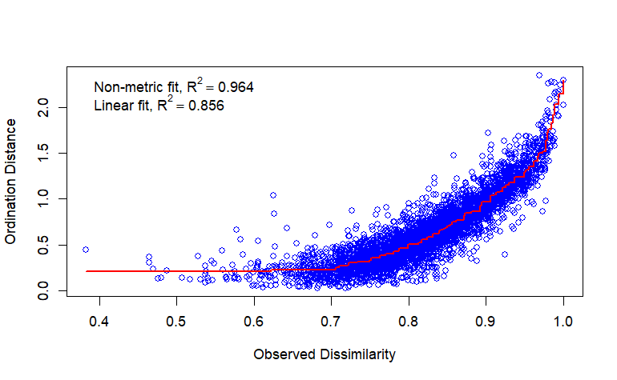

```r
stressplot(nmds)

#add metadata
foram_df %>%
  filter(!Location %in% c("MIS23", "MIS26", "MIS27", "MIS06")) %>%
  dplyr::select(seqid, Location, Habitat, Benthic.group) %>%
  unique()-> foram_metadatr

#calculate significant species
r.species <- envfit(nmds, foram_hellr)
r.species.plot <- as.data.frame(scores(nmds)$species)
r.species.plot$otu <- rownames(r.species.plot)
r.species.plot <- cbind(r.species.plot, pval=r.species$vectors$pvals)
r.species.sig <- subset(r.species.plot, pval<=0.001)
write.csv(r.species.sig, "Rdata/sig_sp_nmds_reef.csv", row.names = TRUE)

# extract species names
foram_sp <-  foram_df[foram_df$X.Identity.percentage > 99.4,]
foram_sp %>%
  dplyr::select(Morphospecies, otu, Large_benthic_foraminifera) %>%
  unique()-> sp_dat

#get asv abundance data
foram_reef %>%
  as.data.frame() %>%
  rownames_to_column("ID") %>%
  pivot_longer(-ID, names_to = "otu", values_to = "nr_reads") -> reef_abund

#join species names to signficant asvs
r.species.sig %>%
  left_join(reef_abund, by = "otu") %>%
  inner_join(sp_dat, by = "otu") -> r.sp.sig

#collapse species to weighted mean
r.sp.sig %>%group_by(Morphospecies) %>%
  summarise(NMDS1 = weighted.mean(NMDS1, nr_reads),
            NMDS2 = weighted.mean(NMDS2, nr_reads)) %>%
  drop_na()-> sig.species

#plot nmds
scores(nmds, display = "sites") %>%
  as_tibble(rownames = "seqid") %>%
  inner_join(foram_metadat, by = "seqid") %>%
  ggplot(aes(x = NMDS1, y = NMDS2, color = Benthic.group)) +
  geom_point(size= 3) +
  scale_color_manual(values = c("hard coral dominated" = "#4B0055", "macro-algae" = "#008298",
                                "macro-algae & hard coral" = "#274983", "rubble - soft coral - encrusting coral" = "#7ED357",
                                "soft coral dominated" = "#FDE333")) +
  stat_ellipse(aes(x = NMDS1, y = NMDS2, color = Benthic.group),
               linetype = "dashed", level = 0.95)+
  ggrepel::geom_text_repel(data=sig.species, inherit.aes = FALSE,
                           aes(NMDS1, NMDS2, label=Morphospecies),  max.overlaps = 50,
                           color = "black", size = 5)+
  ggtitle("Reef") +
  labs(color = "Benthic group dominance") +
  theme_bw() +
  theme(text = element_text(family = "Arial", face = "plain"),
        plot.title = element_text(size = 18),
        legend.text = element_text(size = 14),
        legend.title = element_text(size = 14),
        axis.title = element_text(size = 16, face = "bold")) -> nmds_reef_asv

ggsave("Graphs/nmds_reefasv.svg",
       plot = nmds_reef_asv,
       device = "svg",
       width = 12,
       height = 6,
       dpi = 300)
```

```r
adonis2(foram_hellr ~Benthic.group,data=foram_metadatr,method="bray")
```

```
Permutation test for adonis under reduced model
Permutation: free
Number of permutations: 999

adonis2(formula = foram_hellr ~ Benthic.group, data = foram_metadatr, method = "bray")
         Df SumOfSqs     R2      F Pr(>F)
Model     4    3.403 0.1155 2.6771  0.001 ***
Residual 82   26.059 0.8845
Total    86   29.462 1.0000
---
Signif. codes:  0 ‘***’ 0.001 ‘**’ 0.01 ‘*’ 0.05 ‘.’ 0.1 ‘ ’ 1
```

```r
set.seed(123)
results <- pairwise.adonis(vegdist(foram_hellr,"bray"), foram_metadatr[,4], p.adjust.m = "bonferroni")

library(writexl)
write_xlsx(results, "Rdata/pairwise_nmdsreef.xlsx")
```

Now, the nmds for the marine lakes is calculated.

```r
setwd("C:/Users/Venus/OneDrive/Documents/Github/RajaAmpat_forams")
###----------------------------NMDS plot marine lakes (ASV)--------------------------------------

#make ASV table matrix
foram_df %>%
  filter(Location %in% c("MIS23", "MIS26", "MIS27", "MIS06")) %>%
  dplyr::select(otu, seqid,reads) %>%
  pivot_wider(names_from = otu, values_from = reads, values_fill = list(reads = 0)) %>%
  as.data.frame()-> foram_ml
dim(foram_ml) #19 samples and 763 ASVs
```

```
[1]  19 763
```

```r
rownames(foram_ml) <- foram_ml$seqid
foram_ml <- foram_ml[, -1]
foram_ml <- as.matrix(foram_ml)

#hellinger transformation
foram_hellml <- decostand(foram_ml, method = "hellinger")

#calculate nmds
set.seed(1)
nmdsml <- metaMDS(foram_hellml, distance= "bray", trymax=100, maxit = 1000, k=2) #stress = 0.1155291
```

```
*** Best solution repeated 1 times
```

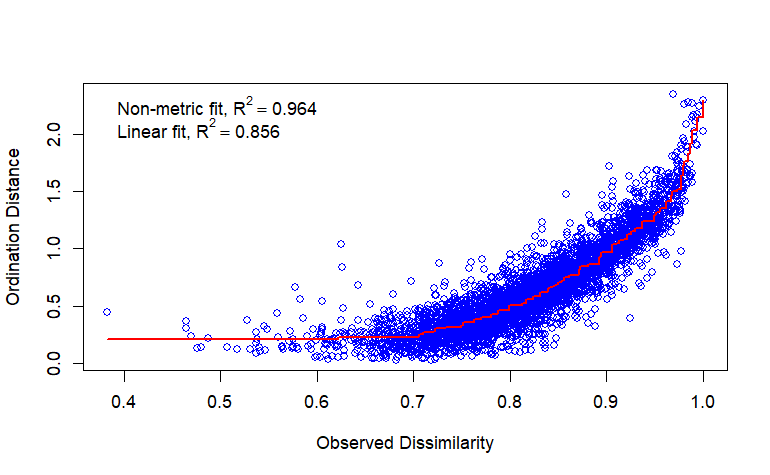

```r
stressplot(nmds)

#add metadata
foram_df %>%
  filter(Location %in% c("MIS23", "MIS26", "MIS27", "MIS06")) %>%
  dplyr::select(seqid, Location, Habitat, Benthic.group) %>%
  unique()-> foram_metadatml

#calculate significant species
ml.species <- envfit(nmdsml, foram_hellml)
ml.species.plot <- as.data.frame(scores(nmdsml)$species)
ml.species.plot$otu <- rownames(ml.species.plot)
ml.species.plot <- cbind(ml.species.plot, pval=ml.species$vectors$pvals)
ml.species.sig <- subset(ml.species.plot, pval<=0.001)
write.csv(ml.species.sig, "Rdata/sig_sp_ml_reef.csv", row.names = TRUE)

# extract family names
foram_sp <-  foram_df[foram_df$X.Identity.percentage > 99.4,]
foram_sp %>%
  dplyr::select(Morphospecies, otu, Large_benthic_foraminifera) %>%
  unique()-> sp_dat

#get asv abundance data
foram_ml %>%
  as.data.frame() %>%
  rownames_to_column("ID") %>%
  pivot_longer(-ID, names_to = "otu", values_to = "nr_reads") -> ml_abund

#join family names to signficant asvs
ml.species.sig %>%
  left_join(ml_abund, by = "otu") %>%
  left_join(sp_dat, by = "otu")-> ml.sp.sig

#collapse families to weighted mean
ml.sp.sig %>%group_by(Morphospecies) %>%
  summarise(NMDS1 = weighted.mean(NMDS1, nr_reads),
            NMDS2 = weighted.mean(NMDS2, nr_reads)) %>%
  drop_na()-> ml.sp

#plot nmds
scores(nmdsml, display = "sites") %>%
  as_tibble(rownames = "seqid") %>%
  inner_join(foram_metadat, by = "seqid") %>%
  ggplot(aes(x = NMDS1, y = NMDS2, color = Benthic.group)) +
  geom_point(size= 3) +
  scale_color_manual(values = c("macro-algae & hard coral" = "#274983",
                                "CCA & Sponge" = "#00B28A", "rubble - soft coral - encrusting coral" = "#7ED357")) +
  stat_ellipse(aes(x = NMDS1, y = NMDS2, color = Benthic.group),
               linetype = "dashed", level = 0.95)+ #95% confidence ellipse
  ggrepel::geom_text_repel(data=ml.sp, inherit.aes = FALSE,
                           aes(NMDS1, NMDS2, label= Morphospecies),  max.overlaps = 50,
                           color = "black", size = 5)+
  ggtitle("Marine Lake") +
  labs(color = "Benthic group dominance") +
  theme_bw() +
  theme(text = element_text(family = "Arial", face = "plain"),
        plot.title = element_text(size = 18),
        legend.text = element_text(size = 14),
        legend.title = element_text(size = 14),
        axis.title = element_text(size = 16, face = "bold")) -> nmds_ml_asv

ggsave("Graphs/nmds_mlasv.svg",
       plot = nmds_ml_asv,
       device = "svg",
       width = 12,                                                                                       # You can play with the ratio of width and height to get the best outcome for each plot
       height = 6,
       dpi = 300)
```

```r
adonis2(foram_hellml ~Benthic.group,data=foram_metadatml,method="bray")
```

```
Permutation test for adonis under reduced model
Permutation: free
Number of permutations: 999

adonis2(formula = foram_hellml ~ Benthic.group, data = foram_metadatml, method = "bray")
         Df SumOfSqs      R2     F Pr(>F)
Model     2   1.1246 0.30235 3.467  0.001 ***
Residual 16   2.5950 0.69765
Total    18   3.7196 1.00000
---
Signif. codes:  0 ‘***’ 0.001 ‘**’ 0.01 ‘*’ 0.05 ‘.’ 0.1 ‘ ’ 1
```

```r
set.seed(123)
results <- pairwise.adonis(vegdist(foram_hellml,"bray"), foram_metadatml[,4], p.adjust.m = "bonferroni")

write_xlsx(results, "Rdata/pairwise_adonis_resultsml.xlsx")
```

**Shannon diversity**